# **Training Neural Networks: Forward Propagation, Loss Functions, Backpropagation**

## **Introduction**

Neural networks have become the cornerstone of modern artificial intelligence, enabling computers to tackle tasks that once seemed impossible — from recognizing faces in photographs to driving autonomous vehicles. But at the heart of all these powerful applications lies a deceptively simple question: **how do these networks learn?** The process of training a neural network is both an art and a science, involving intricate computations that allow the model to discover patterns in data and make accurate predictions. In this paper, we will take a deep and detailed journey into the core mechanisms that govern the training of neural networks. We will explore, with precision and clarity, how data flows through a network (forward propagation), how the network measures its mistakes (loss functions), how it learns to correct those mistakes (backpropagation), and finally, how to navigate the delicate balance between underfitting and overfitting through an understanding of bias and variance. By the end of this discussion, a student new to machine learning should feel confident in their grasp of these fundamental concepts.

## **The Structure of a Neural Network**

Before we delve into the mechanics of training, it is crucial to understand what a neural network is and how it is structured. A neural network, at its core, is a collection of mathematical functions organized in layers. Each layer consists of individual units called neurons. The first layer, known as the input layer, receives raw data — for instance, the pixel intensities of a grayscale image or the numerical features of a dataset in tabular form. This input is then passed through one or more hidden layers, where the real magic happens. Each hidden layer applies transformations to the data by computing weighted sums of inputs and then applying an activation function. These transformations enable the network to learn non-linear relationships in data — relationships that simple linear models could never hope to capture. The final layer, known as the output layer, produces the model’s prediction. Depending on the problem at hand, the output might represent probabilities (in classification tasks) or continuous values (in regression tasks).

Mathematically, the transformation performed by a neuron in layer II can be expressed as:

z^{(l)} = W^{(l)} a^{(l-1)} + b^{(l)}

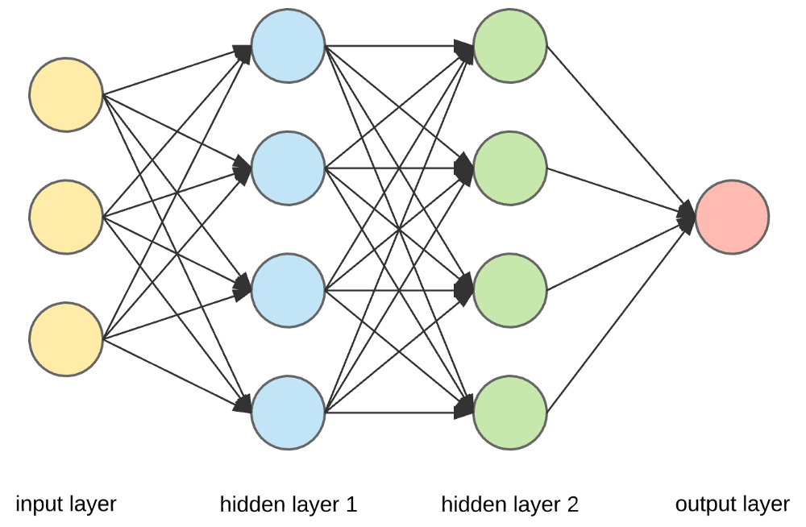

## **Forward Propagation: The Network's First Guess**

Forward propagation is the process by which input data flows through the neural network, layer by layer, until a prediction is produced at the output layer. This process can be thought of as a sequence of transformations applied to the data, each step moving the data closer to the form required for the final decision. Imagine dropping a pebble into a pond and watching the ripples spread outward — forward propagation similarly transmits the input’s influence through the layers of the network.

To understand forward propagation in depth, consider a network designed to classify handwritten digits. The input xx represents the pixel values of an image, typically normalized between 0 and 1. As this input passes through the network, each neuron calculates a weighted sum of the inputs from the previous layer, adds a bias, and applies an activation function. This activation determines whether the neuron 'fires' or not, and how strongly. The intermediate outputs (activations) from one layer become the inputs to the next. This chain continues until the data reaches the output layer, which produces the final prediction y^y^.

Forward propagation is deterministic; given the same input and weights, it will always produce the same output. However, this output is often just an initial guess — the model’s first attempt at solving the problem, without any prior knowledge. This is why we need a way to measure how good or bad this guess is, which brings us to loss functions.

## **Loss Functions: Measuring Prediction Error**

Once the network has produced a prediction through forward propagation, we must assess how well this prediction matches the true label. This is the job of the loss function. The loss function serves as the bridge between the model's outputs and the true values we wish it to predict. It is, in effect, a measure of the model’s failure: a high loss indicates poor predictions, while a low loss indicates the model is on the right track.

where CC is the number of classes.

The loss function is not merely an abstract mathematical construct. It directly influences how the network adjusts its parameters during training. It tells the network how far off its predictions are and guides it toward better performance by defining the direction in which adjustments should be made.

## **Backpropagation: The Engine of Learning**

Having measured the error through the loss function, the network’s job is far from over. The next crucial step is learning from its mistakes — that is, adjusting its internal parameters (weights and biases) to reduce future errors. This is where **backpropagation** comes into play. Backpropagation is not just an algorithm; it is the heart of neural network training, a beautiful application of calculus and linear algebra that enables a model to learn from data.

At its core, backpropagation is about computing how much each weight and bias in the network contributed to the final error. Imagine, for a moment, that the network is a complex system of levers and pulleys. When the output is wrong, we need to figure out which parts of this system were most responsible so that we can adjust them. This involves computing the gradient of the loss function with respect to each parameter — in other words, determining how small changes in each parameter would affect the loss.

where αα is the learning rate — a crucial hyperparameter that controls how large the steps are during training.

This process is repeated for every batch of data, gradually nudging the parameters in directions that reduce the loss. Over time, this leads to a model that fits the data better and better.

## **The Full Training Cycle:**

When we speak of training a neural network, we refer to this cycle of forward propagation, loss computation, backpropagation, and parameter update happening repeatedly, typically over many epochs. An **epoch** refers to one full pass through the training dataset. In practice, for large datasets, we often use mini-batches: subsets of the data that allow us to compute gradients and update parameters more frequently, speeding up convergence and reducing memory usage.

During training, we monitor not just the loss on the training set but also on a separate validation set. The validation loss gives us an estimate of how well the model is generalizing — that is, how well it is likely to perform on unseen data. This brings us to a critical issue in neural network training: the trade-off between bias and variance.

## **Bias: When Models Are Too Simple**

Bias refers to the error introduced by approximating a real-world problem, which may be extremely complex, by a much simpler model. A model with high bias pays too little attention to the training data and fails to capture the underlying patterns. The result is underfitting — the model is unable to make accurate predictions even on the training data, let alone on new examples.

## **Variance: When Models Are Too Complex**

Variance, on the other hand, refers to the model’s sensitivity to small fluctuations in the training data. A model with high variance fits the training data extremely well — perhaps too well. It captures not only the underlying pattern but also the noise present in the training data. The result is overfitting: the model makes excellent predictions on data it has seen but performs poorly on new, unseen data.

where high variance means that the model’s predictions vary greatly depending on the particular training set it saw.

## **The Bias-Variance Trade-Off**

The fundamental challenge in machine learning is managing the trade-off between bias and variance. A model that is too simple (high bias) will fail to capture important regularities in the data. A model that is too complex (high variance) will overfit the noise in the data. The ideal model strikes a balance: complex enough to capture the true patterns but simple enough to generalize to new data.

This trade-off can be visualized by plotting model complexity against error. At low complexity, the error is high due to bias. At high complexity, the error is high due to variance. There is an optimal point in the middle where total error — the sum of bias squared, variance, and irreducible error (noise) — is minimized.

## **Diagnosing Bias and Variance Problems**

Diagnosing whether your model suffers from high bias or high variance is a critical skill. Typically, this is done by comparing the model’s performance on the training data and validation data:

- If the model performs poorly on both training and validation data, it is likely suffering from high bias. The model is too simple to capture the underlying patterns.
- If the model performs well on training data but poorly on validation data, it likely has high variance. The model has learned the training data too well, including its noise, and fails to generalize.

By carefully analyzing learning curves — plots of training and validation error over time — we can gain insights into whether to simplify or complicate the model, or apply other techniques to improve performance.

## **Techniques to Address Bias**

When facing high bias, the primary goal is to increase the model’s capacity. This can be achieved in several ways:  
1️ **Increase model complexity**: Use a deeper network or add more neurons per layer.  
2️**Reduce regularization**: If techniques like dropout or L2 regularization are applied too aggressively, they can constrain the model excessively.  
3️**Train longer**: Sometimes, the model simply needs more epochs to learn adequately.  
4️ **Improve feature engineering**: Provide the model with better input features that capture essential information.

## **Techniques to Address Variance**

Combating high variance involves strategies that encourage the model to focus on the signal rather than the noise:  
1️**Regularization**: Apply L2 regularization (weight decay) or dropout, both of which limit how much individual weights can contribute and help prevent overfitting.  
2️**Increase training data**: More data helps the model learn the true patterns more reliably.  
3️ **Data augmentation**: Particularly in domains like image classification, artificially expanding the dataset through transformations can help.  
4️ **Early stopping**: Monitor validation performance and halt training once overfitting begins.  
5️ **Simplify the model**: Reduce the number of layers or neurons.

## **Conclusion**

Training neural networks is both a technical and conceptual challenge. It requires a deep understanding of how data flows through a network during forward propagation, how error is measured through loss functions, and how learning occurs via backpropagation. Beyond these mechanics, success in training hinges on the delicate art of balancing bias and variance, diagnosing issues as they arise, and applying the right strategies to correct them. By mastering these concepts, one is well-equipped to build neural networks that not only excel on training data but also generalize effectively to solve real-world problems.